# Презентация по лабораторной работе №9

Дисциплина: операционные системы

Лобанова П. И.

Российский университет дружбы народов, Москва, Россия

08.04.2023

# Информация

## Докладчик

- Лобанова Полина Иннокентьевна
- учащаяся факультета физико-математических и естественных наук
- учащаяся направления “Математика и механика”
- Российский университет дружбы народов
- polla-2004@mail.ru

# Цель работы

Познакомиться с операционной системой Linux. Получить практические навыки работы с редактором Emacs.

# Ход работы

## Редактор emacs

Emacs представляет собой мощный экранный редактор текста, написанный на языке высокого уровня Elips.

[figure not shown]

*Редактор emacs.*

## Редактирование файлов

Emacs позволяет редактировать текстовые файлы, в одно нажатие клавиш копировать, вставлять и перемещать текстовые строки.

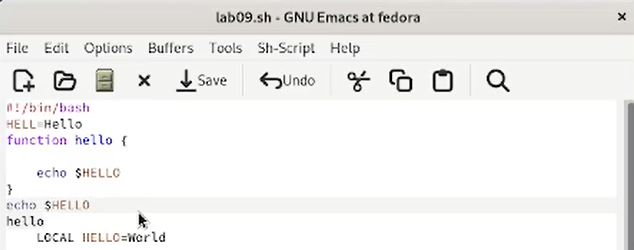

*Редактирование файлов.*

## Переход между буферами

С помощью редактора пользователь может с помощью одной клавиши перейти из одного открытого буфера в другой и работать уже с ним.

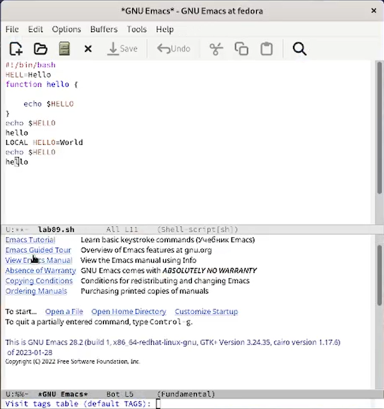

*Переход между буферами.*

## Параллельная работа с несколькими буферами

Также редактор позволяет открыть несколько буферов с одном окне и работать с одним из них с возможностью видеть содержание другого. Для этого используется команда Ctrl-x n, где n - количество частей, на которое нужно разделить окно.

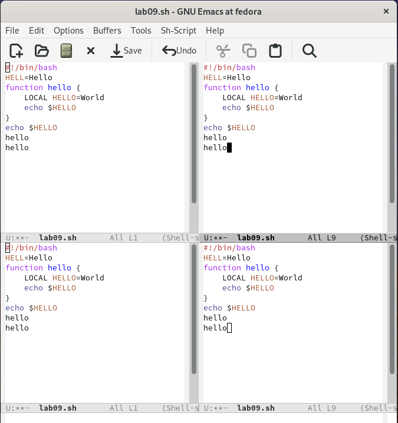

*Параллельная работа с несколькими буферами.*

## Поиск и замена слов

С помощью команды Ctrl-s можно осуществлять поиск по файлам, а с помощью команды Meta-% заменять необходимые части текста другими словами.

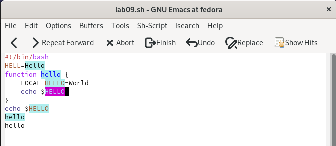

*Поиск и замена слов.*

# Контрольные вопросы

1. Кратко охарактеризуйте редактор emacs.
2. Какие особенности данного редактора могут сделать его сложным для освоения новичком?
3. Своими словами опишите, что такое буфер и окно в терминологии emacs’а.
4. Можно ли открыть больше 10 буферов в одном окне?
5. Какие буферы создаются по умолчанию при запуске emacs?
6. Какие клавиши вы нажмёте, чтобы ввести следующую комбинацию C-c | и C-c C-|?
7. Как поделить текущее окно на две части?
8. В каком файле хранятся настройки редактора emacs?
9. Какую функцию выполняет клавиша и можно ли её переназначить?
10. Какой редактор вам показался удобнее в работе vi или emacs? Поясните почему

# Вывод

Я ознакомилась с операционной системой Linux и получила практические навыки работы с редактором Emacs.